# Stochastic process simulations

We want to study how the state of a system evolves, given a probability of transition from each state.

## What is a stochastic process?

A stochastic process is a collection of random variables $\{X_{t}, t \in I\}$, where $X_{t}$ is the set of random variables at time $t$ and $I$ is the index set of the process.

Stochastic processes are widely used as mathematical models to study:

- the growth of a bacterial population;
- an electrical current fluctuating due to thermal noise;
- the movement of a gas molecule;
- stock prices evolution.

```python
import numpy as np
import matplotlib.pyplot as plt
import random as rn
```

## Simulation of gambler's ruin

We have a gambler who starts with 20 euros.

He can only win or lose 1 euro per bet.

He will keep gambling until he either loses all his money or he wins 40 euros.

He will keep on gambling until he either loses all his money or he wins 40 euros.

$$ X_{t} = \begin{cases} \text{+1 euro, with a probability of 50%} \\ \text{-1 euro, with a probability of 50%} \end{cases} $$

This is an example of a discrete stochastic process.

To implement the process, we can use the function `random.choices`, that handles weighted extractions.

```python
rn.choices([-1, +1], weights=[0.5, 0.5])
```

```
[1]
```

```python
rn.choices([-1, +1], weights=[0.5, 0.5])[0]
```

```
1
```

```python
def gr(g_start, g_goal):
    g_money = g_start
    g_simulations = []
    while g_money in range(1, g_goal):
        event= rn.choices([-1, +1], weights=[0.5, 0.5])[0]
        g_money += event
        g_simulations.append(g_money)
    return g_simulations
```

```python
g_simulation = gr(20, 40)
```

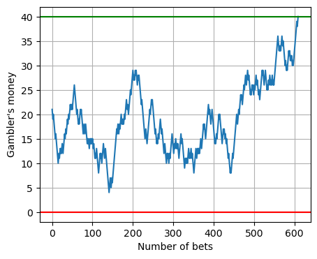

```python
plt.figure(figsize=(5,4))
plt.plot(g_simulation)
plt.axhline(y=0, color='r')
plt.axhline(y=40, color='g')
plt.xlabel('Number of bets')
plt.ylabel('Gambler\'s money')
plt.grid(True)
plt.show()
```

```python
g_simulation = gr(20, 40)
```

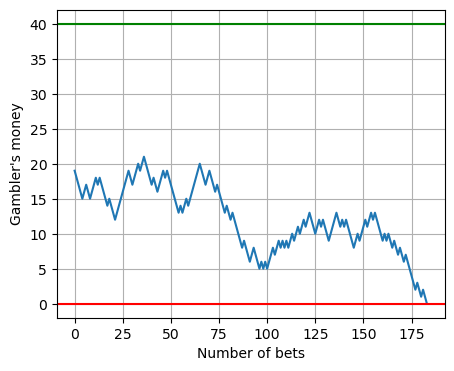

```python
plt.figure(figsize=(5,4))
plt.plot(g_simulation)
plt.axhline(y=0, color='r')
plt.axhline(y=40, color='g')
plt.xlabel('Number of bets')
plt.ylabel('Gambler\'s money')
plt.grid(True)
plt.show()
```

### Mathematical Result for a fair game

Let:

- $p=q=0.5$ (fair coin)
- $x$ = starting money
- $N$ = target money

Then the probability of ruin (reaching 0 before $N$) is: $$ P_{ruin}= 1 - \frac{x}{N} $$

So even if the game is fair:

- if you start with 10 euros and your target is 100 euros → $P_{ruin}=0.9$
- You're very likely to go broke before reaching the goal.

```python
def ruin_prob(g_start, g_goal):
    rp = (g_goal - g_start)/g_goal
    return rp
```

```python
ruin_prob(20, 40)
```

```
0.5
```

```python
final_outcomes = []

while len(final_outcomes) < 10:
    sim = gr(20, 40)
    final_outcomes.append(sim[-1])
```

```python
from collections import Counter
```

```python
distribution = Counter(final_outcomes)
```

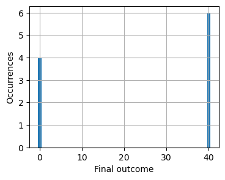

```python
plt.figure(figsize=(4,3))
plt.bar(distribution.keys(), distribution.values())
plt.xlabel('Final outcome')
plt.ylabel('Occurrences')
plt.grid(True)
plt.show()
```

```python
final_outcomes = []

while len(final_outcomes) < 100:
    sim = gr(20, 40)
    final_outcomes.append(sim[-1])
```

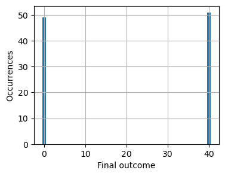

```python
distribution = Counter(final_outcomes)

plt.figure(figsize=(4,3))
plt.bar(distribution.keys(), distribution.values())
plt.xlabel('Final outcome')
plt.ylabel('Occurrences')
plt.grid(True)
plt.show()
```

## Evolution of the number of molecules in an environment

I have a system where I want to keep track of the number of molecules in an environment.

The number of molecules can change due to two different processes:

- a particle from the outside can come in with a probability that is constant (or can be approximated as such);
- a particle can escape the system, with a probability that is constant for each particle (so the total probability is proportional to the number of particles).

```python
def removal(state):
    return state*0.1

def increase(state):
    return 1

transitions = [removal, increase]
transitions_names = ['removal', 'increase']
```

```python
state = 5
```

```python
rates = [f(state) for f in transitions]
rates
```

```
[0.5, 1]
```

## The transition rate

The total rate $\lambda_{tot}$ is the sum of the rates.

The chance of each one happening is the proportion compared to the total rate.

The time for which the system keeps being in the same state is distributed with an exponential time $\tau = \lambda_{tot}^{-1}$.

```python
total_rate = sum(rates)
total_rate
```

```
1.5
```

```python
time = np.random.exponential(1/total_rate)
time
```

```
0.47527288564227765
```

## Choosing the transition

We can use again the function `random.choices`, that handles weighted extractions.

```python
rn.choices(transitions_names, weights=rates)
```

```
['increase']
```

```python
event = rn.choices(transitions_names, weights=rates)[0]
print(event)
```

```
removal
```

## Updating the status

Given the chosen event, we can update the current status and then start all over.

```python
if event == 'increase':
    state += 1
elif event == 'removal':
    state -= 1
else:
    raise ValueError("transition not recognized")
```

## The complete cycle

The complete simulation requires to keep track of which transition happened, how much time the system has spent in each status and so on.

Another thing we might want to keep track of is the total time elapsed in the simulation.

When should we stop our simulation?

Ideally we should stop after a certain amount of "simulated time" has passed.

```python
import typing
from enum import Enum
```

The `typing` library in Python is used to provide **type hints** — annotations that indicate the expected data types of variables, function arguments, and return values. This helps with:

- **Code clarity** – Makes it easier to understand what types a function or variable expects.
- **Static analysis** – Tools like `mypy` and `pyright` can detect bugs before runtime.
- **Autocompletion and documentation** – Improves developer productivity in editors.

The `Enum` function from Python’s built-in `enum` module is used to create enumerations, which are sets of symbolic names bound to unique, constant values. `Enum` makes code more readable, prevent invalid values, and can be compared easily.

Let's see how we can use them to implement our code.

```python
class Transition(Enum):
    INCREASE = 'increase'
    DECREASE = 'removal'

class Observation(typing.NamedTuple):
    state: typing.Any
    time_of_observation: float
    time_of_residency: float
    transition: Transition
```

```python
Observation(5, 1.0, 0.33, Transition.DECREASE)
```

```
Observation(state=5, time_of_observation=1.0, time_of_residency=0.33, transition=<Transition.DECREASE: 'removal'>)
```

```python
transitions = [removal, increase]
transitions_names = [Transition.DECREASE, Transition.INCREASE]
```

```python
observed_states = []
state = 5
total_time = 0.0
time_limit = 5.0

while total_time < time_limit:
    rates = [f(state) for f in transitions]
    total_rate = sum(rates)
    time = np.random.exponential(1/total_rate)
    event = rn.choices(transitions_names, weights=rates)[0]

    observation = Observation(state, total_time, time, event)
    print(observation)
    observed_states.append(observation)

    total_time += time

    if event == Transition.INCREASE:
        state += 1
    elif event == Transition.DECREASE:
        state -= 1
    else:
        raise ValueError("transition not recognized")
```

```
Observation(state=5, time_of_observation=0.0, time_of_residency=0.21813626663082358, transition=<Transition.INCREASE: 'increase'>)
Observation(state=6, time_of_observation=0.21813626663082358, time_of_residency=1.5203882972511142, transition=<Transition.INCREASE: 'increase'>)
Observation(state=7, time_of_observation=1.7385245638819378, time_of_residency=0.30674344562071487, transition=<Transition.DECREASE: 'removal'>)
Observation(state=6, time_of_observation=2.0452680095026525, time_of_residency=1.158292901963256, transition=<Transition.DECREASE: 'removal'>)
Observation(state=5, time_of_observation=3.2035609114659085, time_of_residency=0.8508582197200335, transition=<Transition.INCREASE: 'increase'>)
Observation(state=6, time_of_observation=4.054419131185942, time_of_residency=0.0776217567911968, transition=<Transition.INCREASE: 'increase'>)
Observation(state=7, time_of_observation=4.132040887977139, time_of_residency=0.6037935879212543, transition=<Transition.INCREASE: 'increase'>)
Observation(state=8, time_of_observation=4.735834475898393, time_of_residency=0.03618551105075439, transition=<Transition.INCREASE: 'increase'>)
Observation(state=9, time_of_observation=4.7720199869491475, time_of_residency=0.6986066248906341, transition=<Transition.DECREASE: 'removal'>)
```

Let's make it a function so we have a more general way of managing it.

```python
def simulation(starting_state, time_limit):
    observed_states = []
    state = starting_state
    total_time = 0.0

    while total_time < time_limit:
        rates = [f(state) for f in transitions]
        total_rate = sum(rates)
        time = np.random.exponential(1/total_rate)
        event = rn.choices(transitions_names, weights=rates)[0]

        observation = Observation(state, total_time, time, event)
        observed_states.append(observation)

        total_time += time

        if event == Transition.INCREASE:
            state += 1
        elif event == Transition.DECREASE:
            state -= 1
        else:
            raise ValueError("transition not recognized")
    return observed_states
```

```python
time_limit = 100
result = simulation(starting_state=5, time_limit=time_limit)
```

```python
len(result)
```

```
176
```

```python
for res in result[-5:]:
    print(res)
```

```
Observation(state=6, time_of_observation=98.28968891360317, time_of_residency=0.192645719890583, transition=<Transition.INCREASE: 'increase'>)
Observation(state=7, time_of_observation=98.48233463349375, time_of_residency=0.792877556794792, transition=<Transition.DECREASE: 'removal'>)
Observation(state=6, time_of_observation=99.27521219028854, time_of_residency=0.017821968417441485, transition=<Transition.INCREASE: 'increase'>)
Observation(state=7, time_of_observation=99.29303415870598, time_of_residency=0.3258718222595082, transition=<Transition.INCREASE: 'increase'>)
Observation(state=8, time_of_observation=99.6189059809655, time_of_residency=0.6901424106997316, transition=<Transition.DECREASE: 'removal'>)
```

## Final probability distribution

To estimate the probability of observing our system in a given state, we have to sum up the time the system has spent in each state.

**BEWARE**: the probability depends on the time of residency, not on the number of times that state has appeared!

The expected distribution for this process is a Poisson distribution with average 10.

```python
from collections import Counter

distribution = Counter()
for observation in result:
    state = observation.state
    residency_time = observation.time_of_residency
    distribution[state] += residency_time/time_limit
print(distribution)
```

```
Counter({5: 0.1634088951620872, 9: 0.12635804581993454, 6: 0.11847874786157014, 10: 0.10170817416351323, 4: 0.09623463757719003, 7: 0.07651764527988483, 13: 0.06292214854739374, 12: 0.05528996501592396, 11: 0.05383654745508454, 8: 0.04584220898722135, 14: 0.04367275880962522, 3: 0.03270777349014485,…
```

```python
import scipy.stats as st
```

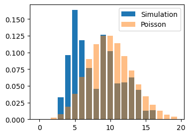

```python
plt.figure(figsize=(4,3))

plt.bar(distribution.keys(), distribution.values(), label='Simulation')

values = np.arange(20)
pmf = st.poisson(10).pmf(values)

plt.bar(values, pmf, alpha=0.5, label='Poisson')
plt.legend(loc='best')
plt.show()
```

Let's make it run for longer.

```python
def generate_distribution(observation_sequence):
    distribution = Counter()
    for observation in observation_sequence:
        state = observation.state
        residency_time = observation.time_of_residency
        distribution[state] += residency_time

    total_time_observed = sum(distribution.values())
    for state in distribution:
        distribution[state] /= total_time_observed
    return distribution
```

```python
time_limit = 1_000
result = simulation(starting_state=5, time_limit=time_limit)
distribution = generate_distribution(result)
```

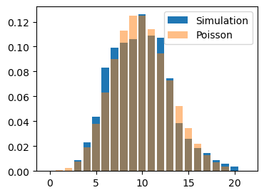

```python
plt.figure(figsize=(4,3))

plt.bar(distribution.keys(), distribution.values(), label='Simulation')

values = np.arange(20)
pmf = st.poisson(10).pmf(values)

plt.bar(values, pmf, alpha=0.5, label='Poisson')
plt.legend(loc='best')
plt.show()
```

## Warm-in period

For monodimensional systems it's relatively easy to converge to the right distribution, but the starting point can have a substancial effect.

```python
time_limit = 1000
result = simulation(starting_state=50, time_limit=time_limit)
distribution = generate_distribution(result)
```

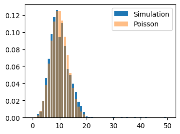

```python
plt.figure(figsize=(4,3))

plt.bar(distribution.keys(), distribution.values(), label='Simulation')

values = np.arange(20)
pmf = st.poisson(10).pmf(values)

plt.bar(values, pmf, alpha=0.5, label='Poisson')
plt.legend(loc='best')
plt.show()
```

## Multiple simulations

Estimating the convergence to the final distribution can be quite hard with a single simulation, so a good rule of thumb is to run at least 3 or 4 identical simulations to assess how much the convergence has been reached

```python
time_limit = 1_000
result_1 = simulation(starting_state=50, time_limit=time_limit)
result_2 = simulation(starting_state=50, time_limit=time_limit)
result_3 = simulation(starting_state=50, time_limit=time_limit)
```

```python
def plot_observations(observation_sequence, ax=None):
    if ax is None:
        ax = plt.gca()
    values = [obs.state for obs in observation_sequence]
    times = [obs.time_of_observation for obs in observation_sequence]
    ax.step(times, values, where='post')
```

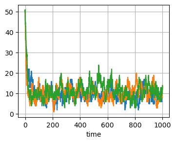

```python
fig = plt.figure(figsize=(4,3))
plot_observations(result_1)
plot_observations(result_2)
plot_observations(result_3)
plt.xlabel('time')
plt.grid(True)
plt.show()
```

```python
distribution_1 = generate_distribution(result_1)
distribution_2 = generate_distribution(result_2)
distribution_3 = generate_distribution(result_3)
```

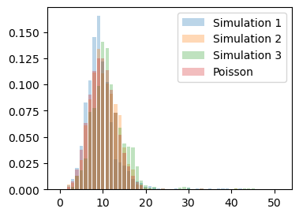

```python
fig = plt.figure(figsize=(4,3))
plt.bar(distribution_1.keys(), distribution_1.values(), alpha=0.3, label='Simulation 1')
plt.bar(distribution_2.keys(), distribution_2.values(), alpha=0.3, label='Simulation 2')
plt.bar(distribution_3.keys(), distribution_3.values(), alpha=0.3, label='Simulation 3')

values = np.arange(20)
pmf = st.poisson(10).pmf(values)

plt.bar(values, pmf, alpha=0.3, label='Poisson')
plt.legend(loc='best')
plt.show()
```

## Absorbing states

An absorbing state is one where the transition rates for all the possible transitions are equal to zero.

When this happens, the expected residency time becomes infinite (the system is stuck there).

Let's rewrite our functions so that 0 is an absorbing state.

```python
class Transition(Enum):
    INCREASE = 'increase'
    DECREASE = 'removal'
    ABSORPION = 'absorbed'
```

```python
def removal_absorbing(state):
    return state*0.5

def increase_absorbing(state):
    return 1 if state>0 else 0

transitions = [removal_absorbing, increase_absorbing]
transitions_names = [Transition.DECREASE, Transition.INCREASE]
```

```python
state = 0
```

```python
rates = [f(state) for f in transitions]
rates
```

```
[0.0, 0]
```

```python
total_rate = sum(rates)
total_rate
```

```
0.0
```

```python
if total_rate>0:
    time = np.random.exponential(1/total_rate)
else:
    time = np.inf
time
```

```
inf
```

At this point we should not be advancing anymore.

```python
def simulation(starting_state, time_limit, transitions, transitions_names):
    observed_states = []
    state = starting_state
    total_time = 0.0

    while total_time < time_limit:
        rates = [f(state) for f in transitions]
        total_rate = sum(rates)
        if total_rate>0:
            time = np.random.exponential(1/total_rate)
            event = rn.choices(transitions_names, weights=rates)[0]
        else:
            time = np.inf
            event = Transition.ABSORPION

        observation = Observation(state, total_time, time, event)
        observed_states.append(observation)

        total_time += time

        if event == Transition.INCREASE:
            state += 1
        elif event == Transition.DECREASE:
            state -= 1
        elif event == Transition.ABSORPION:
            pass
        else:
            raise ValueError("transition not recognized")
    return observed_states
```

```python
result = simulation(5, time_limit=100,
                    transitions=[removal_absorbing, increase_absorbing],
                    transitions_names=[Transition.DECREASE, Transition.INCREASE])
```

```python
for observation in result:
    print(observation)
```

```
Observation(state=5, time_of_observation=0.0, time_of_residency=0.1295581979304522, transition=<Transition.DECREASE: 'removal'>)
Observation(state=4, time_of_observation=0.1295581979304522, time_of_residency=0.4139340180049431, transition=<Transition.DECREASE: 'removal'>)
Observation(state=3, time_of_observation=0.5434922159353953, time_of_residency=0.06892822075957937, transition=<Transition.DECREASE: 'removal'>)
Observation(state=2, time_of_observation=0.6124204366949747, time_of_residency=0.08605006228768515, transition=<Transition.DECREASE: 'removal'>)
Observation(state=1, time_of_observation=0.6984704989826599, time_of_residency=1.3318730062311341, transition=<Transition.DECREASE: 'removal'>)
Observation(state=0, time_of_observation=2.030343505213794, time_of_residency=inf, transition=<Transition.ABSORPION: 'absorbed'>)
```

## Fixed time events

One possibility we might be interested in could be to register events happening at fixed point in time (or space, if we are describing the movement of an object).

The advantage of working with markovian transitions is that there is no problem interrupting at a fixed point in time and then keep going from there as nothing happened.

```python
class Transition(Enum):
    INCREASE = 'increase'
    DECREASE = 'removal'
    ABSORPION = 'absorbed'
    RINGTONE = 'ringtone'
```

```python
def removal_absorbing(state):
    return state*0.5

def increase_absorbing(state):
    return 1 if state>0 else 0

transitions = [removal_absorbing, increase_absorbing]
transitions_names = [Transition.DECREASE, Transition.INCREASE]
```

```python
state = 5
```

```python
rates = [f(state) for f in transitions]
rates
```

```
[2.5, 1]
```

```python
total_rate = sum(rates)
total_rate
```

```
3.5
```

```python
proposed_residency_time = np.random.exponential(1/total_rate)
proposed_residency_time
```

```
0.47185245098380235
```

```python
current_time = 0.1
```

```python
time_ringtone = 0.3
```

```python
if current_time<time_ringtone and current_time + proposed_residency_time > time_ringtone:
    proposed_residency_time = time_ringtone - current_time
    event = Transition.RINGTONE
else:
    pass
```

```python
event
```

```
<Transition.RINGTONE: 'ringtone'>
```

Now we have to decide how to interact with the absorbing states.

A good practice is to prioritize timed events.

```python
def simulation(starting_state, time_limit, transitions, transitions_names):
    observed_states = []
    state = starting_state
    total_time = 0.0

    while total_time < time_limit:
        rates = [f(state) for f in transitions]
        total_rate = sum(rates)
        if total_rate>0:
            time = np.random.exponential(1/total_rate)
            event = rn.choices(transitions_names, weights=rates)[0]
        else:
            time = np.inf
            event = Transition.ABSORPION

        # the fixed events overrides the others if they would happen before the chosen time
        time_ringtone = 1.0
        if total_time < time_ringtone and total_time + time > time_ringtone:
            time = time_ringtone - total_time
            event = Transition.RINGTONE

        observation = Observation(state, total_time, time, event)
        observed_states.append(observation)

        total_time += time

        if event == Transition.INCREASE:
            state += 1
        elif event == Transition.DECREASE:
            state -= 1
        elif event == Transition.ABSORPION or event == Transition.RINGTONE:
            pass
        else:
            raise ValueError("transition not recognized")
    return observed_states
```

```python
result = simulation(5, time_limit=100,
                    transitions=[removal_absorbing, increase_absorbing],
                    transitions_names=[Transition.DECREASE, Transition.INCREASE])
```

```python
for observation in result[:6]:
    print(observation)
```

```
Observation(state=5, time_of_observation=0.0, time_of_residency=0.02831309367205282, transition=<Transition.DECREASE: 'removal'>)
Observation(state=4, time_of_observation=0.02831309367205282, time_of_residency=0.18884813064301723, transition=<Transition.DECREASE: 'removal'>)
Observation(state=3, time_of_observation=0.21716122431507004, time_of_residency=0.16264063024863004, transition=<Transition.DECREASE: 'removal'>)
Observation(state=2, time_of_observation=0.3798018545637001, time_of_residency=0.005867363635311678, transition=<Transition.INCREASE: 'increase'>)
Observation(state=3, time_of_observation=0.38566921819901173, time_of_residency=0.6143307818009882, transition=<Transition.RINGTONE: 'ringtone'>)
Observation(state=3, time_of_observation=1.0, time_of_residency=0.380225645672309, transition=<Transition.INCREASE: 'increase'>)
```

## Continuous time Markov Chain

This is an exact simulation algorithm for continuous-time Markov chains and represents the basics for the generalization to the continuous time random walk simulation.

The idea of rate-driven random events in continuous time is at the core of many particle-transport simulations and is widely used to generate realistic synthetic data for imaging and deep learning, even if the implementation is usually more specialized.

## Exercise

There are still many things that can be done to implement this simulator:

1. return the simulation not as a list, but as a dedicated object that can:
   - be sliced over time: `my_simulation[0.5:100.0]`;
   - have a plot function dedicated
   - automatically estimate the distribution
2. always include multiple runs of the simulation, and join this with point 1
3. allow the user to specify the effect of the various transitions